# p2

```python
from simplex import *
```

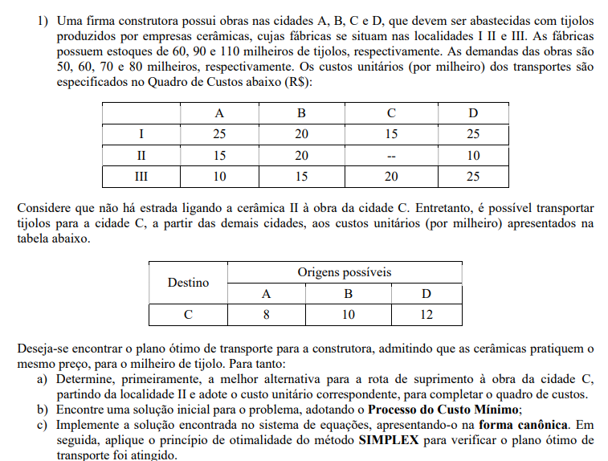

```python
Image('Opera Instantâneo_2023-05-22_135815_Prova2_DCA0115_2023-1.pdf.png')
```

Para encontrar a melhor rota da fábrica II até C, faremos um quadro dos custos possíveis:

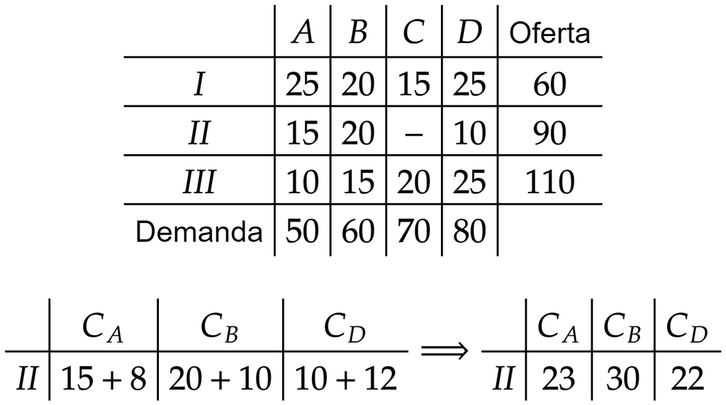

```python
Image('C:/Users/glori/Downloads/math-20230522 (3).png')
```

Como podemos ver, a melhor opção para entregar produtos saindo da fábrica 2 para C será enviando por D. Assim, nosso quadro de custos final fica:

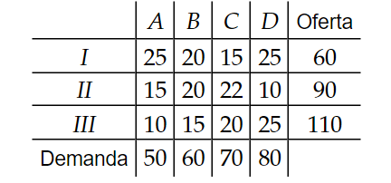

```python
Image("Opera Instantâneo_2023-05-22_140023_www.mathcha.io.png")
```

Agora, para achar uma solução inicial:

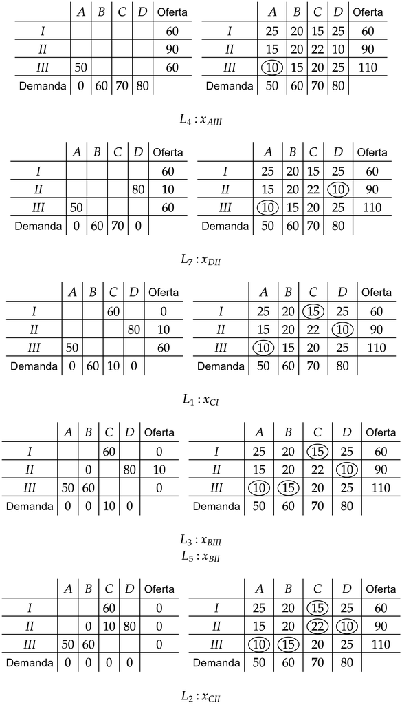

```python
Image('C:/Users/glori/Downloads/math-20230522 (4).png')
```

A solução inicial foi:

$ \begin{cases} x_{AI} = 0 \\ x_{AII} = 0 \\ x_{AIII} = 50 \\ x_{BI} = 0 \\ x_{BII} = 0 \\ x_{BIII} = 60 \\ x_{CI} = 60 \\ x_{CII} = 10 \\ x_{CIII} = 0 \\ x_{DI} = 0 \\ x_{DII} = 80 \\ x_{DIII} = 0 \\ \end{cases} $

Agora, para achar uma solução ótima, via maximização do simétrico:

```python
z = [[25, 15, 10, 20, 20, 15, 15, 22, 20, 25, 10, 25], [True, True, True, True, True, True, True, True, True, True, True, True]]
varSubs = ['AI', 'AII', 'AIII','BI', 'BII', 'BIII','CI', 'CII', 'CIII','DI', 'DII', 'DIII']
r = [[1, 0, 0, 1, 0, 0, 1, 0, 0, 1, 0, 0, '=', 60],
     [0, 1, 0, 0, 1, 0, 0, 1, 0, 0, 1, 0, '=', 90],
     [0, 0, 1, 0, 0, 1, 0, 0, 1, 0, 0, 1, '=', 110],
     [1, 1, 1, 0, 0, 0, 0, 0, 0, 0, 0, 0, '=', 50],
     [0, 0, 0, 1, 1, 1, 0, 0, 0, 0, 0, 0, '=', 60],
     [0, 0, 0, 0, 0, 0, 1, 1, 1, 0, 0, 0, '=', 70],
     [0, 0, 0, 0, 0, 0, 0, 0, 0, 1, 1, 1, '=', 80]]

m = makeMatrix(z, r, True)
printTable(m, z, '-Z', varSubs)
```

[output not shown]

Agora, para incorporar a solução inicial na tabela, farei $x_{CI}$ base na linha 1:

```python
makePivot(m, 1, 6, z, '-Z', varSubs)
printTable(m, z, '-Z', varSubs)
```

Agora, fazer $x_{CII}$ base na linha 2:

```python
makePivot(m, 2, 7, z, '-Z', varSubs)
printTable(m, z, '-Z', varSubs)
```

$x_{BIII}$ base na linha 3:

```python
makePivot(m, 3, 5, z, '-Z', varSubs)
printTable(m, z, '-Z', varSubs)
```

$x_{AIII}$ base na linha 4:

```python
makePivot(m, 4, 2, z, '-Z', varSubs)
printTable(m, z, '-Z', varSubs)
```

$x_{BII}$ base na linha 5:

```python
makePivot(m, 5, 4, z, '-Z', varSubs)
printTable(m, z, '-Z', varSubs)
```

e, por fim, fazer $x_{DII}$ base na linha 7:

```python
makePivot(m, 7, 10, z, '-Z', varSubs)
printTable(m, z, '-Z', varSubs)
```

[output not shown]

$ \begin{cases} x_{AI} = 0 \\ x_{AII} = 0 \\ x_{AIII} = 50 \\ x_{BI} = 0 \\ x_{BII} = 0 \\ x_{BIII} = 60 \\ x_{CI} = 60 \\ x_{CII} = 10 \\ x_{CIII} = 0 \\ x_{DI} = 0 \\ x_{DII} = 80 \\ x_{DIII} = 0 \\ \end{cases} $

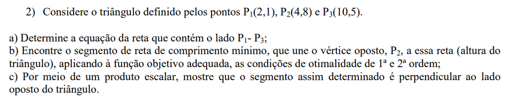

```python
Image("./Opera Instantâneo_2023-05-22_143055_Prova2_DCA0115_2023-1.pdf.png")
```

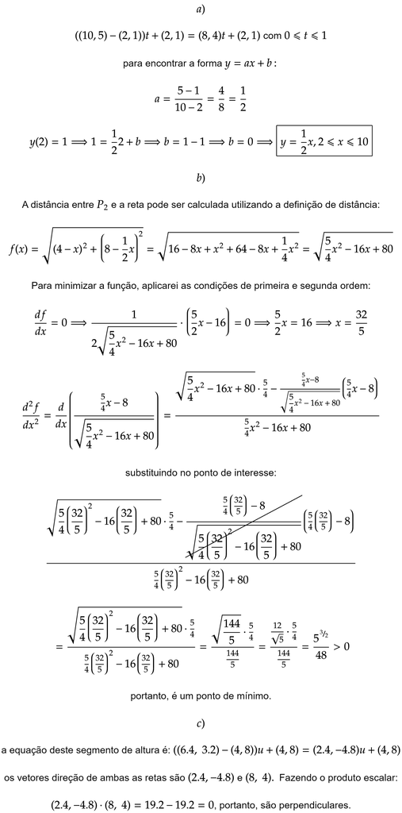

```python
Image("C:/Users/glori/Downloads/math-20230522 (5).png")
```